# An Example of Intransitive Dependence

Simulation notebook

SoSe 25

```r
if (!require("ggplot2")) install.packages("ggplot2"); library(ggplot2)
if (!require("dplyr")) install.packages("dplyr"); library(dplyr)
if (!require("gridExtra")) install.packages("gridExtra"); library(gridExtra)
if (!require("dagitty")) install.packages("dagitty"); library(dagitty)
if (!require("ggdag")) install.packages("ggdag"); library(ggdag)
if (!require("patchwork")) install.packages("patchwork"); library(patchwork)
if (!require("MetBrewer")) install.packages("MetBrewer"); library(MetBrewer)
```

Goals:

- See a special case where dependence doesn’t follow intuitively

## Case of Intransitive Dependence

Here we will briefly follow [Causal Inference in Statistics: A Primer](https://ebookcentral.proquest.com/lib/unitueb/detail.action?docID=4383483), p. 38, to see an example where no dependence flows between $X$ and $Y$ along the $X \rightarrow Z \rightarrow Y$ path.

Here is our SCM:

$$\begin{align*}
V &= \{X, Z, Y\}, \quad U = \{U_X, U_Z, U_Y\}, \quad F = \{f_X, f_Z,
f_Y\} \\
f_X &: X = U_X \\
f_Z &: Z = \begin{cases}
a & \text{if } X = 1 \text{ and } U_Z = 1 \\
b & \text{if } X = 2 \text{ and } U_Z = 1 \\
c & \text{if } U_Z = 2
\end{cases} \\
f_Y &: Y = \begin{cases}
i & \text{if } Z = c \text{ or } U_Y = 1 \\
j & \text{if } U_Y = 2
\end{cases}
\end{align*}$$

And the respective DAG:

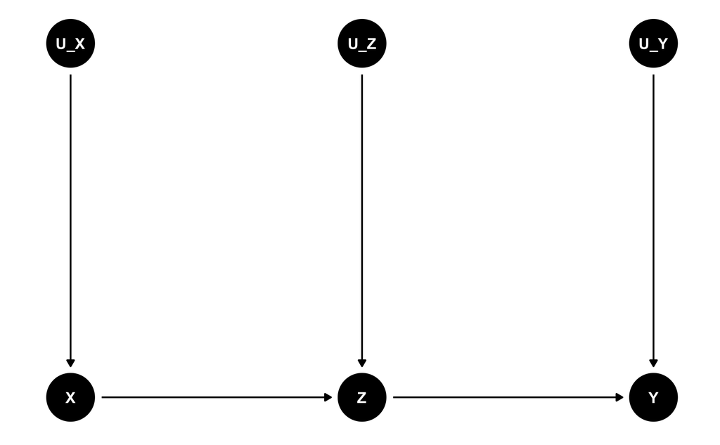

```r
dag <- dagitty("dag {
  U_X -> X
  U_Z -> Z
  U_Y -> Y
  X -> Z
  Z -> Y}")

coordinates(dag) <- list(
  x = c(U_X = 0,   X = 0,   Z = 1,   Y = 2,   U_Z = 1,   U_Y = 2),
  y = c(U_X = 2,   X = 1,   Z = 1,   Y = 1,   U_Z = 2,   U_Y = 2))

ggdag(dag) + theme_dag()
```

In this case, no matter what value $U_Z$ and $U_Y$ take, $X$ will have no effect on the value that $Y$ takes; changes in $X$ account for variation in $Z$ between $a$ and $b$, but $Z$ doesn’t affect $Y$ unless it takes the value $c$. Therefore, $X$ and $Y$ vary independently in this model.

Another way to see this is to generate data consistent with the SCM and check for dependencies.

Let’s start by simulating the data:

```r
set.seed(123)

n <- 1000

# U_X, U_Z, U_Y follow discrete uniform distribution over {1,2}
U_X <- sample(1:2, n, replace = TRUE)
U_Z <- sample(1:2, n, replace = TRUE)
U_Y <- sample(1:2, n, replace = TRUE)

# Generate X, Z and Y
X <- U_X

Z <- rep(NA, n)
for (i in 1:n) {
  if (U_Z[i] == 1 && X[i] == 1) {
    Z[i] <- "a"
  } else if (U_Z[i] == 1 && X[i] == 2) {
    Z[i] <- "b"
  } else if (U_Z[i] == 2) {
    Z[i] <- "c"
  }}

Y <- rep(NA, n)
for (i in 1:n) {
  if (Z[i] == "c" || U_Y[i] == 1) {
    Y[i] <- "i"
  } else if (U_Y[i] == 2) {
    Y[i] <- "j"
}}

scm_data <- data.frame(X, Y, Z, U_X, U_Y, U_Z) %>%
  mutate(across(c(X, Y, Z), as.factor))
```

We can now check the marginal distributions (probability mass functions, PMFs):

```r
prop.table(table(scm_data$X, dnn = "X"))
```

```
X
    1     2
0.506 0.494
```

```r
prop.table(table(scm_data$Z, dnn = "Z"))
```

```
Z
    a     b     c
0.264 0.251 0.485
```

```r
prop.table(table(scm_data$Y, dnn = "Y"))
```

```
Y
    i     j
0.753 0.247
```

and the conditional PMFs:

```r
table_ZX <- table(Z = scm_data$Z, X = scm_data$X)
prop.table(table_ZX, margin = 2)
```

```
   X
Z           1         2
  a 0.5217391 0.0000000
  b 0.0000000 0.5080972
  c 0.4782609 0.4919028
```

```r
table_YZ <- table(Y = scm_data$Y, Z = scm_data$Z)
prop.table(table_YZ, margin = 2)
```

```
   Z
Y           a         b         c
  i 0.5303030 0.5099602 1.0000000
  j 0.4696970 0.4900398 0.0000000
```

```r
table_YX <- table(Y = scm_data$Y, X = scm_data$X)
prop.table(table_YX, margin = 2)
```

```
   X
Y           1         2
  i 0.7549407 0.7510121
  j 0.2450593 0.2489879
```

One can see here that

$$\mathbb{P}(Y = y \mid X = 1) = \mathbb{P}(Y = y \mid X = 2) =
\mathbb{P}(Y = y) \quad \text{for all } y.$$

That is, conditioning on $X$ does not change the distribution of $Y$; in other words, $X$ and $Y$ are independent.

We conclude with a visual re-statement of the same result:

```r
# For nice colors
pal_X <- met.brewer("VanGogh3", 2)
pal_Z <- met.brewer("Hiroshige", 3)
pal_Y <- met.brewer("OKeeffe2", 2)

base_theme <- theme(axis.text = element_text(size = 7),
                    axis.title = element_text(size = 7),
                    plot.title = element_text(size = 8, face = "bold"))

# 1. Histogram of X
p1 <- ggplot(scm_data, aes(x = X, fill = X)) + geom_bar() + scale_fill_manual(values = pal_X) +
  coord_cartesian(ylim = c(0, 750)) + labs(title = "P(X = x)") + base_theme

# 2. Histogram of Z by X
p2 <- ggplot(scm_data, aes(x = Z, fill = X)) + geom_bar(position = "stack") +
  scale_fill_manual(values = pal_X) + coord_cartesian(ylim = c(0, 750)) +
  labs(title = "P(Z = z) by X") + base_theme

# 3. Histogram of Y by X
p3 <- ggplot(scm_data, aes(x = Y, fill = X)) + geom_bar(position = "stack") +
  scale_fill_manual(values = pal_X) + coord_cartesian(ylim = c(0, 750)) +
  labs(title = "P(Y = y) by X", fill = "X") + base_theme +
  theme(legend.position = "right", legend.direction = "vertical")

# 4. Histogram of Z
p4 <- ggplot(scm_data, aes(x = Z, fill = Z)) + geom_bar() + labs(title = "P(Z = z)") +
  scale_fill_manual(values = pal_Z) + coord_cartesian(ylim = c(0, 750)) + base_theme

# 5. Histogram of Y by Z
p5 <- ggplot(scm_data, aes(x = Y, fill = Z)) + geom_bar(position = "stack") +
  scale_fill_manual(values = pal_Z) + coord_cartesian(ylim = c(0, 750)) +
  labs(title = "P(Y = y) by Z") + base_theme +
  theme(legend.position = "right", legend.direction = "vertical")

# 6. Histogram of Y
p6 <- ggplot(scm_data, aes(x = Y, fill = Y)) + geom_bar() +
  scale_fill_manual(values = pal_Y) + coord_cartesian(ylim = c(0, 750)) +
  labs(title = "P(Y = y)") + base_theme +
  theme(legend.position = "right", legend.direction = "vertical")

# Combine the plots together
empty <- plot_spacer()
plot <- (p1 | p2 | p3) /
  (empty | p4 | p5) /
  (empty | empty | p6) +
  plot_layout(guides = "collect")
```

[output not shown]

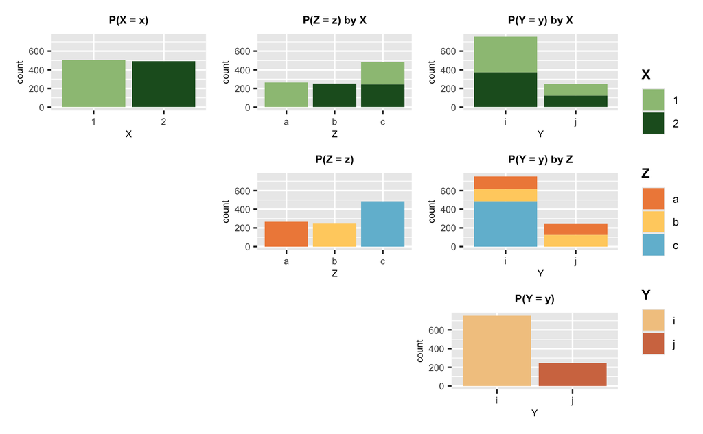

```r
plot
```

Here we can again see that the conditional distribution of $Y$ does not change with respect to $X$ (right upper corner panel, $Y$ being “i” or “j” is equally likely for different $X$).

Given the causal path $X \rightarrow Z \rightarrow Y$ and the setting we have constructed, $X$ and $Z$, as well as $Z$ and $Y$, are pairwise dependent, but $X$ and $Y$ are independent.